# STAT 400 - GLM Milestone 2 & EDA

Ishan Agrahar, Jake Sturges, Noah Tobias, Prajwal Bhandari

2025-12-03

Our goal of this logistic regression is to predict whether a team will make the playoffs and as such our response variable will be a binary response which takes values of (1) for a team that made the playoffs and (0) for a team that did not make the playoffs.

A single observation in this dataset will be a NBA team during a given season.

## FRONT MATTER

```r
# Libraries
library(tidyverse)
library(janitor)
library(skimr)
library(GGally)
```

```r
# Datasets
## Raw Data Source Link: https://github.com/NocturneBear/NBA-Data-2010-2024/blob/main/regular_season_totals_2010_2024.csv
NBAGameData <- read.csv("regular_season_totals_2010_2024.csv")
## I manually made a csv from this site using Google Sheets: https://basketball.realgm.com/nba/playoffs/history/2010
NBAPlayoffTeamsPerYear <- read.csv("NBA_Playoff_Data.csv")
```

## GLM MILESTONE1 & GLM MILESTONE2 DATA CLEANING

```r
NBATeamData <- NBAGameData %>%
  # grouped by season and team so each observation is a team in a given season
  group_by(SEASON_YEAR,TEAM_NAME) %>%
# creating relevant variables for dataset
  summarise(FGA = mean(FGA),
            FGM = mean(FGM),
            FG_PCT = mean(FG_PCT),
            FG3M = mean(FG3M),
            FG3A = mean(FG3A),
            FG3_PCT = mean(FG3_PCT),
            FTM = mean(FTM),
            FTA = mean(FTA),
            FTPCT = mean(FT_PCT),
            OREB = mean(OREB),
            DREB = mean(DREB),
            REB = mean(REB),
            AST = mean(AST),
            TOV = mean(TOV),
            STL = mean(STL),
            BLK = mean(BLK),
            BLKA = mean(BLKA),
            PF = mean(PF),
            PFD = mean(PFD),
            PTS = mean(PTS),
            PLUS_MINUS = mean(PLUS_MINUS),
            WINPCT = mean(ifelse(WL == "W",1,0)),
            .groups = "drop") %>%
  mutate(CONFERENCE = ifelse(TEAM_NAME %in% c("Denver Nuggets","Minnesota Timberwolves","Oklahoma City Thunder","Utah Jazz","Portland Trail Blazers","Golden State Warriors","LA Clippers", "Los Angeles Clippers","Los Angeles Lakers", "Phoenix Suns","Sacramento Kings", "Dallas Mavericks","Houston Rockets","Memphis Grizzlies", "New Orleans Pelicans","San Antonio Spurs","New Orleans Hornets"), "Western", "Eastern"))

# Dataset does not include whether team has made playoffs so will need to join
## See NBAPlayoffTeamsPerYear

## I just copied and pasted playoffs occurrences, which is a comma separated string, into the Years Column so I just need to go through each team and indicate 1 if the Year is in the string and 0 otherwise.
NBAPlayoffTeamsPerYear <-
  NBAPlayoffTeamsPerYear %>%
  mutate(
    `2010-11` = ifelse(grepl("2011", Years), 1, 0),
    `2011-12` = ifelse(grepl("2012", Years), 1, 0),
    `2012-13` = ifelse(grepl("2013", Years), 1, 0),
    `2013-14` = ifelse(grepl("2014", Years), 1, 0),
    `2014-15` = ifelse(grepl("2015", Years), 1, 0),
    `2015-16` = ifelse(grepl("2016", Years), 1, 0),
    `2016-17` = ifelse(grepl("2017", Years), 1, 0),
    `2017-18` = ifelse(grepl("2018", Years), 1, 0),
    `2018-19` = ifelse(grepl("2019", Years), 1, 0),
    `2019-20` = ifelse(grepl("2020", Years), 1, 0),
    `2020-21` = ifelse(grepl("2021", Years), 1, 0),
    `2021-22` = ifelse(grepl("2022", Years), 1, 0),
    `2022-23` = ifelse(grepl("2023", Years), 1, 0),
    `2023-24` = ifelse(grepl("2024", Years), 1, 0)
  ) %>%
  pivot_longer(cols = starts_with("20"),
               names_to = "SEASON_YEAR", # For consistency with original dataset
               values_to = "PlayoffAppearanceIndicator") %>%
  rename(TEAM_NAME = Team.Name) %>%
  .[, -2] # Removing the Years Column since don't need it anymore and need to join

## Comparing team names, Uncomment below if you wanna see this
# setdiff(unique(NBAPlayoffTeamsPerYear$TEAM_NAME), unique(NBATeamData$TEAM_NAME))
# setdiff(unique(NBATeamData$TEAM_NAME), unique(NBAPlayoffTeamsPerYear$TEAM_NAME))
# Differences are [1] "Philadelphia Sixers", & "Charlotte Bobcats"   "New Jersey Nets"     "New Orleans Hornets" "Philadelphia 76ers"  "LA Clippers"

## Manually Fix Inconsistencies
NBAPlayoffTeamsPerYear$TEAM_NAME[NBAPlayoffTeamsPerYear$TEAM_NAME == "Philadelphia Sixers"] <- "Philadelphia 76ers"
NBATeamData$TEAM_NAME[NBATeamData$TEAM_NAME == "Charlotte Bobcats"] <- "Charlotte Hornets"
NBATeamData$TEAM_NAME[NBATeamData$TEAM_NAME == "New Jersey Nets"] <- "Brooklyn Nets"
NBATeamData$TEAM_NAME[NBATeamData$TEAM_NAME == "New Orleans Hornets"] <- "New Orleans Pelicans"
NBATeamData$TEAM_NAME[NBATeamData$TEAM_NAME == "LA Clippers"] <- "Los Angeles Clippers"

## Validate
# setdiff(unique(NBAPlayoffTeamsPerYear$TEAM_NAME), unique(NBATeamData$TEAM_NAME))
# setdiff(unique(NBATeamData$TEAM_NAME), unique(NBAPlayoffTeamsPerYear$TEAM_NAME))

## Perform Join of NBAPlayoffTeamsPerYear and NBATeamData
NBATeamData <-
  left_join(NBATeamData,
            NBAPlayoffTeamsPerYear,
            by=c("TEAM_NAME", "SEASON_YEAR"))

## Perform save, Uncomment below if you want it
#write_csv(NBATeamData, "CleanedData/NBATeamData.csv")
```

## GLM Milestone2 EDA

### Create Playoff Appearance Factor Variable & Basic Summaries

```r
## label playoff factor once for plots below

NBATeamData <- NBATeamData %>%
  mutate(
    PlayoffAppearance = factor(
      PlayoffAppearanceIndicator,
      levels = c(0, 1),
      labels = c("No Playoffs", "Playoffs")
    )
  )

## missing values and dataset summary

colSums(is.na(NBATeamData))
```

```
##                SEASON_YEAR                  TEAM_NAME
##                          0                          0
##                        FGA                        FGM
##                          0                          0
##                     FG_PCT                       FG3M
##                          0                          0
##                       FG3A                    FG3_PCT
##                          0                          0
##                        FTM                        FTA
##                          0                          0
##                      FTPCT                       OREB
##                          0                          0
##                       DREB                        REB
##                          0                          0
##                        AST                        TOV
##                          0                          0
##                        STL                        BLK
##                          0                          0
##                       BLKA                         PF
##                          0                          0
##                        PFD                        PTS
##                          0                          0
##                 PLUS_MINUS                     WINPCT
##                          0                          0
##                 CONFERENCE PlayoffAppearanceIndicator
##                          0                          0
##          PlayoffAppearance
##                          0
```

```r
glimpse(NBATeamData)
```

```
## Rows: 420
## Columns: 27
## $ SEASON_YEAR                <chr> "2010-11", "2010-11", "2010-11", "2010-11",…
## $ TEAM_NAME                  <chr> "Atlanta Hawks", "Boston Celtics", "Charlot…
## $ FGA                        <dbl> 78.40244, 75.84146, 77.62195, 80.32927, 81.…
## $ FGM                        <dbl> 36.23171, 36.86585, 35.03659, 37.09756, 35.…
## $ FG_PCT                     <dbl> 0.4633780, 0.4869390, 0.4521220, 0.4632317,…
## $ FG3M                       <dbl> 6.121951, 4.975610, 4.792683, 6.231707, 6.2…
## $ FG3A                       <dbl> 17.40244, 13.64634, 14.67073, 17.25610, 18.…
## $ FG3_PCT                    <dbl> 0.3594878, 0.3614512, 0.3195854, 0.3603293,…
## $ FTM                        <dbl> 16.41463, 17.79268, 18.42683, 18.19512, 18.…
## $ FTA                        <dbl> 21.07317, 23.10976, 24.37805, 24.48780, 25.…
## $ FTPCT                      <dbl> 0.7732683, 0.7677683, 0.7552927, 0.7420122,…
## $ OREB                       <dbl> 9.292683, 7.792683, 10.341463, 11.792683, 1…
## $ DREB                       <dbl> 30.00000, 31.00000, 29.80488, 32.36585, 29.…
## $ REB                        <dbl> 39.29268, 38.79268, 40.14634, 44.15854, 40.…
## $ AST                        <dbl> 21.97561, 23.42683, 21.07317, 22.28049, 20.…
## $ TOV                        <dbl> 13.63415, 14.57317, 14.53659, 14.15854, 14.…
## $ STL                        <dbl> 6.060976, 8.243902, 6.390244, 7.219512, 6.6…
## $ BLK                        <dbl> 4.158537, 4.195122, 5.280488, 5.707317, 4.1…
## $ BLKA                       <dbl> 4.243902, 4.439024, 6.048780, 5.817073, 5.9…
## $ PF                         <dbl> 18.95122, 20.46341, 19.96341, 19.98780, 20.…
## $ PFD                        <dbl> 18.50000, 20.23171, 21.09756, 20.06098, 21.…
## $ PTS                        <dbl> 95.00000, 96.50000, 93.29268, 98.62195, 95.…
## $ PLUS_MINUS                 <dbl> -0.8170732, 5.3658537, -4.0000000, 7.317073…
## $ WINPCT                     <dbl> 0.5365854, 0.6829268, 0.4146341, 0.7560976,…
## $ CONFERENCE                 <chr> "Eastern", "Eastern", "Eastern", "Eastern",…
## $ PlayoffAppearanceIndicator <dbl> 1, 1, 0, 1, 0, 1, 1, 0, 0, 0, 1, 0, 1, 1, 1…
## $ PlayoffAppearance          <fct> Playoffs, Playoffs, No Playoffs, Playoffs, …
```

```r
skimr::skim(NBATeamData)
```

Data summary

| Name | NBATeamData |
| --- | --- |
| Number of rows | 420 |
| Number of columns | 27 |
| _______________________ |  |
| Column type frequency: |  |
| character | 3 |
| factor | 1 |
| numeric | 23 |
| ________________________ |  |
| Group variables | None |

**Variable type: character**

| skim_variable | n_missing | complete_rate | min | max | empty | n_unique | whitespace |
| --- | --- | --- | --- | --- | --- | --- | --- |
| SEASON_YEAR | 0 | 1 | 7 | 7 | 0 | 14 | 0 |
| TEAM_NAME | 0 | 1 | 9 | 22 | 0 | 30 | 0 |
| CONFERENCE | 0 | 1 | 7 | 7 | 0 | 2 | 0 |

**Variable type: factor**

| skim_variable | n_missing | complete_rate | ordered | n_unique | top_counts |
| --- | --- | --- | --- | --- | --- |
| PlayoffAppearance | 0 | 1 | FALSE | 2 | Pla: 224, No : 196 |

**Variable type: numeric**

| skim_variable | n_missing | complete_rate | mean | sd | p0 | p25 | p50 | p75 | p100 | hist |
| --- | --- | --- | --- | --- | --- | --- | --- | --- | --- | --- |
| FGA | 0 | 1 | 85.64 | 3.63 | 75.84 | 82.82 | 85.87 | 88.30 | 94.38 | ▁▆▇▇▂ |
| FGM | 0 | 1 | 39.35 | 2.40 | 33.23 | 37.68 | 39.18 | 41.27 | 47.01 | ▂▇▇▅▁ |
| FG_PCT | 0 | 1 | 0.46 | 0.02 | 0.41 | 0.45 | 0.46 | 0.47 | 0.51 | ▁▅▇▅▁ |
| FG3M | 0 | 1 | 9.87 | 2.80 | 3.77 | 7.66 | 10.06 | 12.01 | 16.74 | ▃▇▇▆▂ |
| FG3A | 0 | 1 | 27.54 | 7.43 | 11.29 | 21.41 | 28.36 | 33.31 | 45.38 | ▃▇▇▇▂ |
| FG3_PCT | 0 | 1 | 0.36 | 0.02 | 0.29 | 0.34 | 0.36 | 0.37 | 0.41 | ▁▂▇▅▁ |
| FTM | 0 | 1 | 17.44 | 1.70 | 12.24 | 16.29 | 17.38 | 18.48 | 24.11 | ▁▇▇▂▁ |
| FTA | 0 | 1 | 22.76 | 2.20 | 16.57 | 21.17 | 22.69 | 24.15 | 31.09 | ▁▇▇▂▁ |
| FTPCT | 0 | 1 | 0.77 | 0.03 | 0.66 | 0.75 | 0.77 | 0.79 | 0.84 | ▁▂▇▇▂ |
| OREB | 0 | 1 | 10.51 | 1.24 | 7.62 | 9.64 | 10.46 | 11.32 | 14.59 | ▂▇▇▃▁ |
| DREB | 0 | 1 | 32.94 | 2.03 | 27.20 | 31.64 | 33.07 | 34.24 | 42.23 | ▂▇▇▁▁ |
| REB | 0 | 1 | 43.44 | 2.09 | 36.88 | 42.05 | 43.46 | 44.72 | 51.70 | ▁▅▇▂▁ |
| AST | 0 | 1 | 23.37 | 2.42 | 18.02 | 21.55 | 23.23 | 25.02 | 30.76 | ▂▇▇▃▁ |
| TOV | 0 | 1 | 14.21 | 1.10 | 11.10 | 13.45 | 14.17 | 14.94 | 17.72 | ▁▅▇▃▁ |
| STL | 0 | 1 | 7.62 | 0.81 | 5.54 | 7.06 | 7.60 | 8.20 | 10.03 | ▁▆▇▃▁ |
| BLK | 0 | 1 | 4.88 | 0.75 | 2.38 | 4.35 | 4.82 | 5.33 | 8.17 | ▁▇▇▂▁ |
| BLKA | 0 | 1 | 4.88 | 0.71 | 2.99 | 4.42 | 4.85 | 5.37 | 6.89 | ▁▅▇▅▁ |
| PF | 0 | 1 | 20.03 | 1.44 | 15.65 | 18.95 | 20.04 | 21.05 | 24.76 | ▁▆▇▃▁ |
| PFD | 0 | 1 | 20.03 | 1.31 | 16.21 | 19.14 | 20.03 | 20.83 | 24.30 | ▁▅▇▃▁ |
| PTS | 0 | 1 | 106.00 | 7.28 | 86.95 | 100.19 | 105.79 | 112.29 | 123.29 | ▂▆▇▇▂ |
| PLUS_MINUS | 0 | 1 | -0.01 | 4.71 | -13.91 | -3.17 | 0.43 | 3.24 | 11.63 | ▁▃▇▇▁ |
| WINPCT | 0 | 1 | 0.50 | 0.15 | 0.11 | 0.39 | 0.51 | 0.61 | 0.89 | ▂▆▇▇▁ |
| PlayoffAppearanceIndicator | 0 | 1 | 0.53 | 0.50 | 0.00 | 0.00 | 1.00 | 1.00 | 1.00 | ▇▁▁▁▇ |

```r
head(NBATeamData)
```

```
## # A tibble: 6 × 27
##   SEASON_YEAR TEAM_NAME   FGA   FGM FG_PCT  FG3M  FG3A FG3_PCT   FTM   FTA FTPCT
##   <chr>       <chr>     <dbl> <dbl>  <dbl> <dbl> <dbl>   <dbl> <dbl> <dbl> <dbl>
## 1 2010-11     Atlanta …  78.4  36.2  0.463  6.12  17.4   0.359  16.4  21.1 0.773
## 2 2010-11     Boston C…  75.8  36.9  0.487  4.98  13.6   0.361  17.8  23.1 0.768
## 3 2010-11     Charlott…  77.6  35.0  0.452  4.79  14.7   0.320  18.4  24.4 0.755
## 4 2010-11     Chicago …  80.3  37.1  0.463  6.23  17.3   0.360  18.2  24.5 0.742
## 5 2010-11     Clevelan…  81.1  35.2  0.435  6.21  18.2   0.341  18.9  25.3 0.743
## 6 2010-11     Dallas M…  78.8  37.4  0.475  7.87  21.6   0.364  17.5  22.6 0.775
## # ℹ 16 more variables: OREB <dbl>, DREB <dbl>, REB <dbl>, AST <dbl>, TOV <dbl>,
## #   STL <dbl>, BLK <dbl>, BLKA <dbl>, PF <dbl>, PFD <dbl>, PTS <dbl>,
## #   PLUS_MINUS <dbl>, WINPCT <dbl>, CONFERENCE <chr>,
## #   PlayoffAppearanceIndicator <dbl>, PlayoffAppearance <fct>
```

Based on the above there seems to be no missing variables for any of the dataset. Based on the above there are 14 seasons worth of data (2010-2024). For our research the most important variable that we are trying to predict is playoff appearance, as this indicates whether a team made/will make the playoffs based on our model. While as of right now its not clear which variables will be most important, some that will likely have a high impact are PTS, PLUS_MINUS, FG_PCT, and FG3_PCT. One variable purposefully excluded from that is win_percentage as using that is kind of pointless in our prediction since win_pct% directly indicates playoff teams as the 8 highest win_pct teams in each conference automatically make the playoffs.

## Univariate EDA

### We will focus on two variables of interest since bivariate will likely provide better insights

### Distribution of Win Percentages by teams over 2010-2024 Seasons

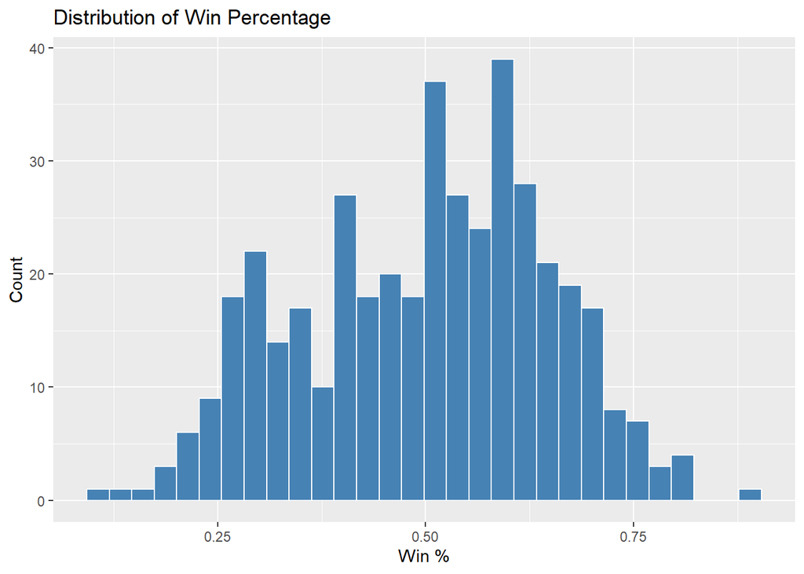

```r
## Win pct for teams

ggplot(NBATeamData, aes(x = WINPCT)) +
geom_histogram(bins = 30, fill = "steelblue", color = "white") +
labs(
title = "Distribution of Win Percentage",
x = "Win %",
y = "Count"
)
```

### Points Per Game

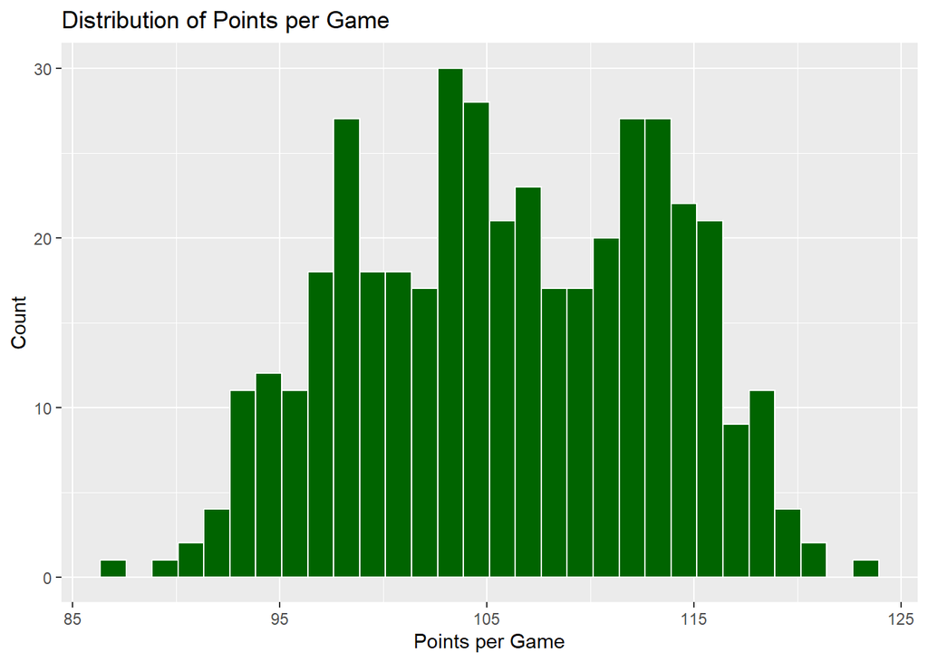

```r
## Points per game for teams

ggplot(NBATeamData, aes(x = PTS)) +
geom_histogram(bins = 30, fill = "darkgreen", color = "white") +
labs(
title = "Distribution of Points per Game",
x = "Points per Game",
y = "Count"
)
```

Points per Game seems to be centered around 105 points with certain teams averaging as little as 87 pointers per game, with others averaging as high as 123 points per game. One prediction we have is that teams which score more have a higher likelihood of making the playoffs (obviously dependent on their defense).

## Bivariate EDA

### Points Per Game by Playoff vs. Non-Playoff Teams

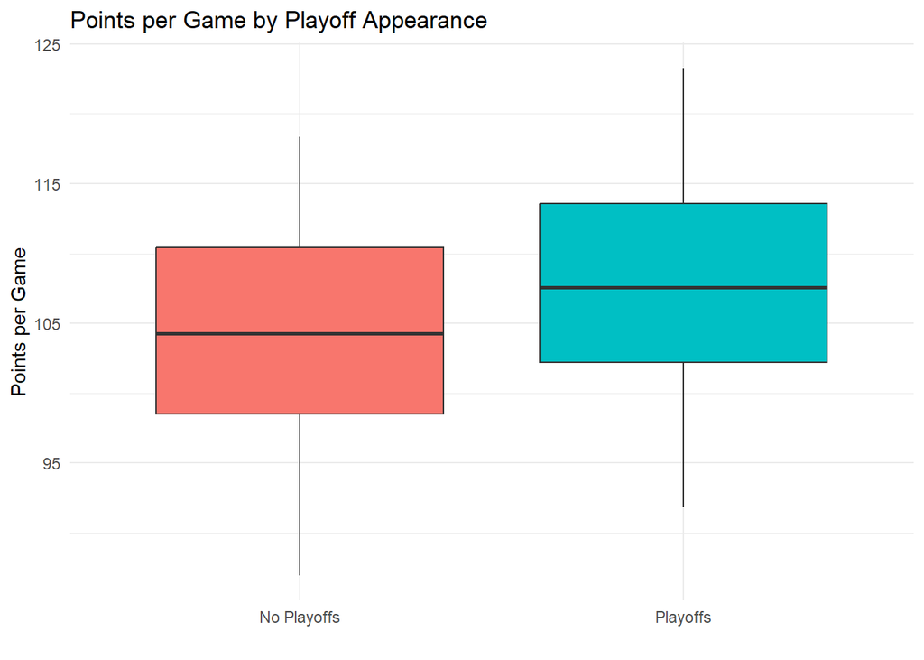

```r
## Points

ggplot(NBATeamData, aes(x = PlayoffAppearance, y = PTS, fill = PlayoffAppearance)) +
  geom_boxplot(show.legend = FALSE) +
  labs(
    title = "Points per Game by Playoff Appearance",
    x = "",
    y = "Points per Game"
  ) +
  theme_minimal()
```

### Field Goal Percentage by Playoff Teams vs. Non-Playoff Teams

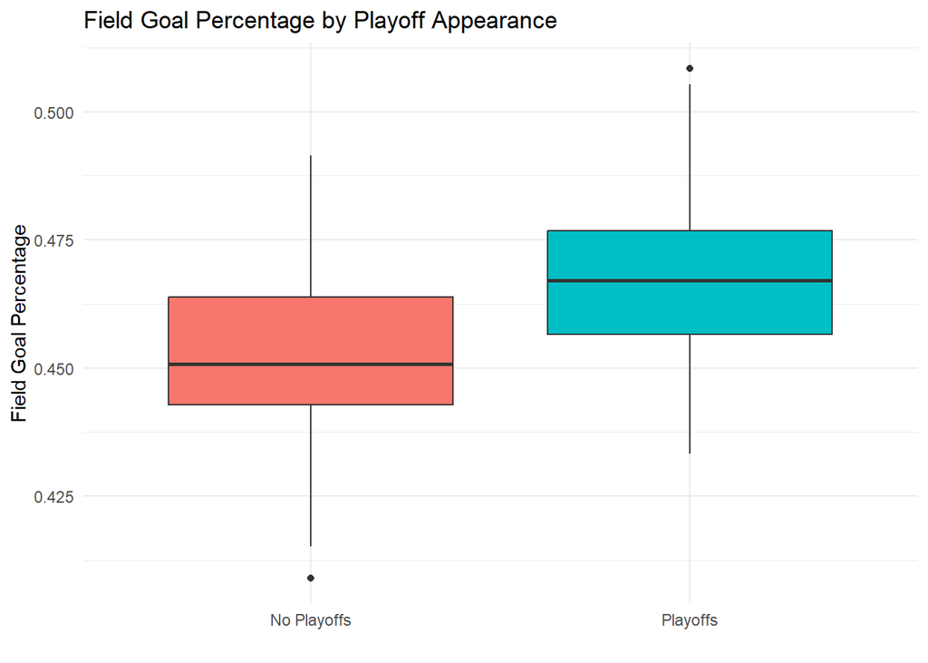

```r
## Field Goal Pct

ggplot(NBATeamData, aes(x = PlayoffAppearance, y = FG_PCT, fill = PlayoffAppearance)) +
  geom_boxplot(show.legend = FALSE) +
  labs(
    title = "Field Goal Percentage by Playoff Appearance",
    x = "",
    y = "Field Goal Percentage"
  ) +
  theme_minimal()
```

Another seemingly high impact variable is field goal percentage and it is clear that teams which made the playoffs tended to have an almost 2% better field goal percentage than non-playoff teams.

### Turnovers by Playoff vs. Non-Playoff Teams

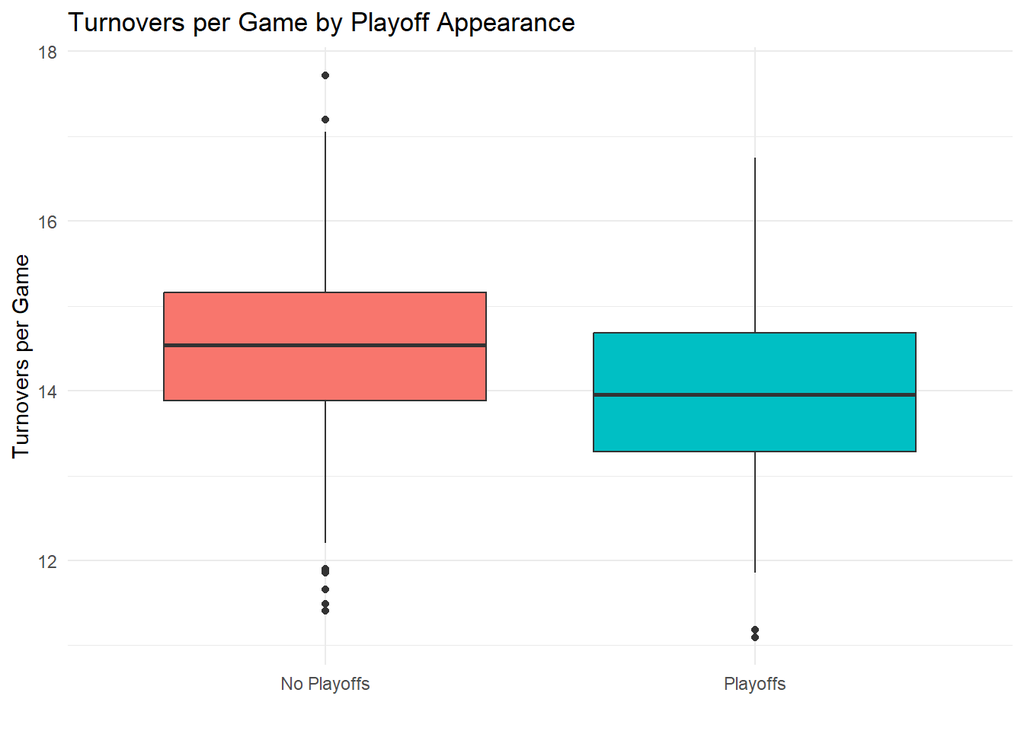

```r
## Turnovers

ggplot(NBATeamData, aes(x = PlayoffAppearance, y = TOV, fill = PlayoffAppearance)) +
  geom_boxplot(show.legend = FALSE) +
  labs(
    title = "Turnovers per Game by Playoff Appearance",
    x = "",
    y = "Turnovers per Game"
  ) +
  theme_minimal()
```

Another variable that may have been overlooked earlier is turnovers. It is clear that playoff teams turn the ball over less than non-playoff teams. This highlights that other variables besides points scored could be a great indicator of whether a team will be successful.